# The Bernoulli Distribution

# 1 Probability Mass Function

A random variable is said to have a Bernoulli Distribution with parameter $p$ if its probability mass function is: $p(x)=\left\{ \begin{array}{ll} p^x(1-p)^{1-x}, & x=0,1\\ 0 & \mathrm{otherwise} \end{array} \right.$ Where $p$ is the probability of a sucess.

# 2 Cumulative Distribution Function

$P(x)=\left\{ \begin{array}{lll} 0 & x<0\\ 1-p & x=0\\ 1 & 1\leq x \end{array} \right.$

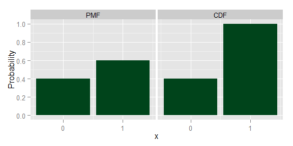

# 3 Expected Values

$\begin{align} E(X) &= \sum\limits_{i=0}^{1} x\cdot p(x)\\ &= \sum\limits_{i=0}^{1} x \cdot p^{x} (1-p)^{1-x}\\ &= 0 \cdot p^{0} (1-p)^{1-0} + 1 \cdot p^{1} (1-p)^{1-1}\\ &= 0 + p (1-p)^{0} \\ &= p \end{align}$

$\begin{align} E(X^{2}) &= \sum\limits_{i=0}^{1} x^2 \cdot p(x)\\ &= \sum\limits_{i=0}^{1} x^{2} \cdot p^x (1-p)^{1-x}\\ &= \sum\limits_{i=0}^{1} 0^{2} \cdot p^0 (1-p)^{1-0} + 1^2 \cdot p^1 (1-p)^{1-1}\\ &= 0 \cdot 1 \cdot 1 + 1 \cdot p \cdot 1\\ &= 0 + p \\ &= p \end{align}$

$\mu = E(X) = p$

$\sigma^2 = E(X^2) - E(X)^2 = p-p^2 = p(1-p)$

# 4 Moment Generating Function

$\begin{align} M_{X}(t) &= E(e^{tX}) = \sum\limits_{i=0}^{1} e^{tx} p(x) = \sum\limits_{i=0}^{1} e^{tx} p^{x} (1-p)^{1-x}\\ &= e^{t0} p^0 (1-p)^{1-0} + e^t p^t (1-p)^{1-1} = (1-p) + e^t p =pe^t + (1-p) \end{align}$

$M^{(1)}_X(t) = pe^t$ $M^{(2)}_X(t) = pe^t$

$E(X) =M^{(1)}_X(0) = pe^0 = p \cdot 1 = p$

$E(X^2) = M^{(2)}_X(0) = pe^0 = p$

$\mu = E(X) = p$

$\sigma^2 = E(X^2) - E(X)^2 = p - p^2 = p (1-p)$

# 5 Theorems for the Bernoulli Distribution

## 5.1 Validity of the Distribution

$\sum\limits_{x=0}^{1}p^x(1-p)^{1-x}=1$

*Proof:*

$\sum\limits_{x=0}^{1} p^x (1-p)^{1-x} = p^0 (1-p)^1 + p^1 (1-p)^0 = (1-p) + p = 1$

## 5.2 Sum of Bernoulli Random Variables

Let $X_1,X_2,\ldots,X_n$ be independent and identically distributed random variables from a Bernoulli distribution with parameter $p$. Let $Y=\sum\limits_{i=1}^{n}X_i$.  
Then $Y\sim$ Binomial$(n,p)$

*Proof:* $\begin{align} M_Y(t) = E(e^{tY}) = E(e^{tX_1} e^{tX_2} \cdots e^{tX_n}) = E(e^{tX_1}) E(e^{tX_2}) \cdots E(e^{tX_n})\\ &= (pe^t+(1-p)) (pe^t+(1-p)) \cdots (pe^t+(1-p)) = (pe^t+(1-p))^n \end{align}$ Which is the mgf of a Binomial random variable with parameters $n$ and $p$.  
Thus, $Y\sim$ Binomial$(n,p)$.